# Stochastic Differential Equations

## 1. Reading an SDE as an integral equation

Chapter 6 considers equations of the form

$$ dX_t=\mu(t,X_t)\,dt+\sigma(t,X_t)\,dB_t. $$

A solution is a continuous adapted process for which the corresponding integrals are well-defined and

$$ X_t=X_0+\int_0^t\mu(s,X_s)\,ds +\int_0^t\sigma(s,X_s)\,dB_s $$

holds for every time in the stated interval, almost surely. The notation $dX_t$ is therefore read through accumulated increments, not as an ordinary pathwise derivative.

In Example 6.1, $\mu$ and $\sigma$ are constants, so

$$ X_t=X_0+\mu t+\sigma B_t. $$

The deterministic term $\mu t$ supplies the accumulated drift, while $\sigma B_t$ supplies the accumulated diffusion.

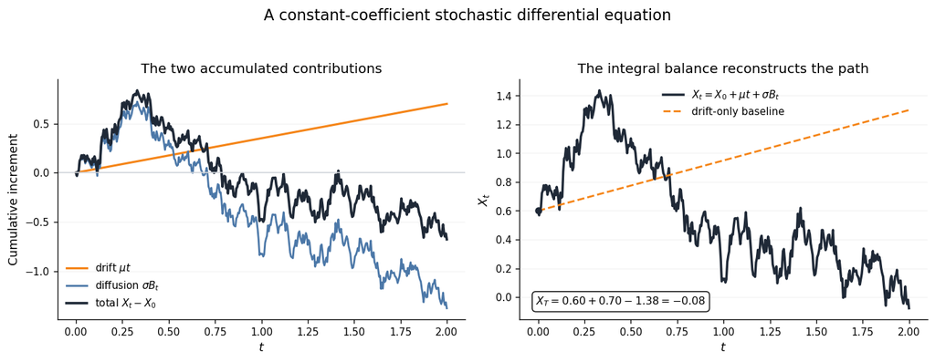

**Figure 1.** Drift, diffusion, and their sum for $X_t=X_0+\mu t+\sigma B_t$, with $X_0=0.6$, $\mu=0.35$, $\sigma=0.8$, and one Brownian path on $[0,2]$.

Interpretation. The left panel reads the SDE cumulatively: the orange curve is the finite-variation contribution, the blue curve is the stochastic contribution, and the black curve is their sum. Adding $X_0$ gives the path on the right. These equalities are exact at the displayed grid points because Example 6.1 supplies the explicit solution; the grid only selects where the path is shown.

## 2. Matching coefficients: geometric Brownian motion

Example 6.2 studies

$$ dX_t=\mu X_t\,dt+\sigma X_t\,dB_t. $$

With the ansatz $X_t=f(t,B_t)$, Itô's formula gives

$$ df(t,B_t) =\left(\partial_t f+\frac12\partial_{xx}f\right)(t,B_t)\,dt +\partial_xf(t,B_t)\,dB_t. $$

Matching the $dt$ and $dB_t$ coefficients yields

$$ \partial_xf=\sigma f, \qquad \partial_tf+\frac12\partial_{xx}f=\mu f. $$

Solving these equations gives

$$ X_t=X_0\exp\left(\left(\mu-\frac{\sigma^2}{2}\right)t+\sigma B_t\right). $$

The tempting expression $Y_t=X_0e^{\mu t+\sigma B_t}$ omits the Itô correction. Applying Itô's formula to $Y$ shows that it instead solves

$$ dY_t=\left(\mu+\frac{\sigma^2}{2}\right)Y_t\,dt+\sigma Y_t\,dB_t. $$

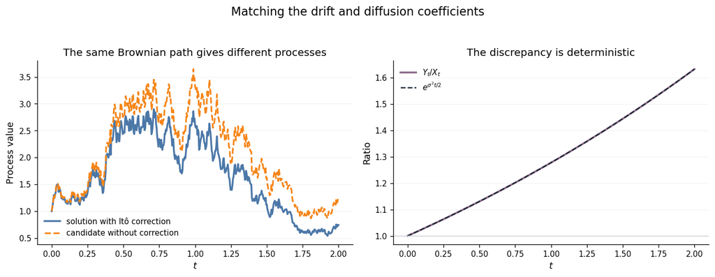

**Figure 2.** The geometric Brownian solution and the candidate without the $-\sigma^2t/2$ correction, using $X_0=1$, $\mu=0.25$, $\sigma=0.7$, and the same Brownian path.

Interpretation. The two curves separate even though they use identical noise. Their ratio is exactly $e^{\sigma^2t/2}$, so the discrepancy is not Monte Carlo or grid error. Coefficient matching identifies the corrected process as the solution of the stated SDE; the uncorrected candidate has the larger drift $\mu+\sigma^2/2$.

## 3. Changing the ansatz: the Ornstein-Uhlenbeck process

Example 6.3 considers

$$ dX_t=-\alpha X_t\,dt+\sigma\,dB_t, \qquad X_0=x_0, $$

where $\alpha,\sigma>0$. If $X_t=f(t,B_t)$, matching the diffusion coefficient requires $\partial_xf=\sigma$, so $f(t,x)=\sigma x+g(t)$. The drift equation would then require

$$ g'(t)=-\alpha\left(\sigma x+g(t)\right), $$

which cannot hold for every $x$. This failure concerns the restricted ansatz, not the existence of a solution.

Using a deterministic integrating factor instead gives

$$ X_t=e^{-\alpha t}x_0 +\sigma\int_0^t e^{-\alpha(t-s)}\,dB_s. $$

The Itô isometry then yields the exact moments

$$ \mathbb E[X_t]=x_0e^{-\alpha t}, \qquad \operatorname{Var}(X_t) =\frac{\sigma^2}{2\alpha}\left(1-e^{-2\alpha t}\right). $$

Consequently, $X_t$ converges in distribution to $\mathcal N\left(0,\sigma^2/(2\alpha)\right)$ as $t\to\infty$.

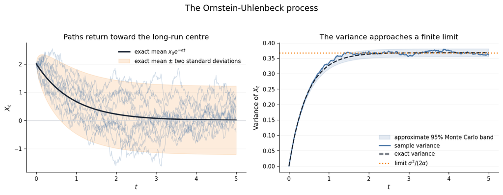

**Figure 3.** Ornstein-Uhlenbeck paths and variance estimates for $x_0=2$, $\alpha=1.1$, and $\sigma=0.9$, using 6,000 paths generated by the exact Gaussian transition on 500 observation intervals.

Interpretation. The drift $-\alpha X_t$ points toward zero, while the diffusion continues to introduce random variation. The exact mean decays to zero and the exact variance increases toward $\sigma^2/(2\alpha)$. The sample variance tracks that formula within the displayed pointwise Monte Carlo band. The moment formulas establish these limits; the simulated paths display their finite-sample appearance.

## 4. What the existence and uniqueness theorem guarantees

Let $T>0$. With the usual measurability setup for the coefficients, Theorem 6.4 assumes that there is a constant $k>0$ such that, for every $x,y\in\mathbb R$ and $t\in[0,T]$,

$$ |\mu(t,x)-\mu(t,y)|^2 +|\sigma(t,x)-\sigma(t,y)|^2 \leq k|x-y|^2, $$

and

$$ |\mu(t,x)|^2+|\sigma(t,x)|^2 \leq k\left(1+|x|^2\right). $$

The first condition is a global Lipschitz bound in the state variable. The second is a linear-growth bound after taking square roots.

| Condition | Role in the proof |
| --- | --- |
| Global Lipschitz bound | Controls differences between two solutions and between successive Picard iterates. |
| Linear-growth bound | Keeps the drift and diffusion terms square-integrable on the finite interval. |
| $x_0\in L^2(\Omega)$ | Supplies a square-integrable initial value; if random, $x_0$ is understood to be $\mathcal F_0$-measurable. |

Under these assumptions, there is a continuous adapted solution on $[0,T]$ satisfying

$$ \sup_{t\in[0,T]}\mathbb E[|X_t|^2]<\infty. $$

If $Y$ is another continuous adapted, uniformly $L^2$-bounded solution driven by the same Brownian motion and with the same initial value, then

$$ \mathbb P\left(X_t=Y_t\text{ for every }t\in[0,T]\right)=1. $$

The conditions are sufficient, not necessary: failing one of them does not by itself show that an SDE has no solution or no unique solution.

## 5. The factorial mechanism behind uniqueness

Let $X$ and $Y$ be two solutions in the class specified by Theorem 6.4. Subtracting their integral equations gives

$$ X_t-Y_t =\int_0^t\left(\mu(s,X_s)-\mu(s,Y_s)\right)ds +\int_0^t\left(\sigma(s,X_s)-\sigma(s,Y_s)\right)dB_s. $$

Minkowski's inequality, Cauchy-Schwarz, the Itô isometry, and the Lipschitz condition imply that

$$ g(t)\leq A\int_0^t g(s)\,ds, \qquad g(t):=\mathbb E[|X_t-Y_t|^2], $$

where $A=k(1+\sqrt T)^2$. Since $g$ is bounded on $[0,T]$, repeated substitution yields, for every $n\geq1$,

$$ 0\leq g(t) \leq \frac{A^nt^n}{n!}\,\lVert g\rVert_\infty. $$

For each fixed $t$, the right-hand side tends to zero as $n\to\infty$. Thus $g(t)=0$. Applying this first at rational times and then using continuity gives equality of the two paths for every $t\in[0,T]$, almost surely.

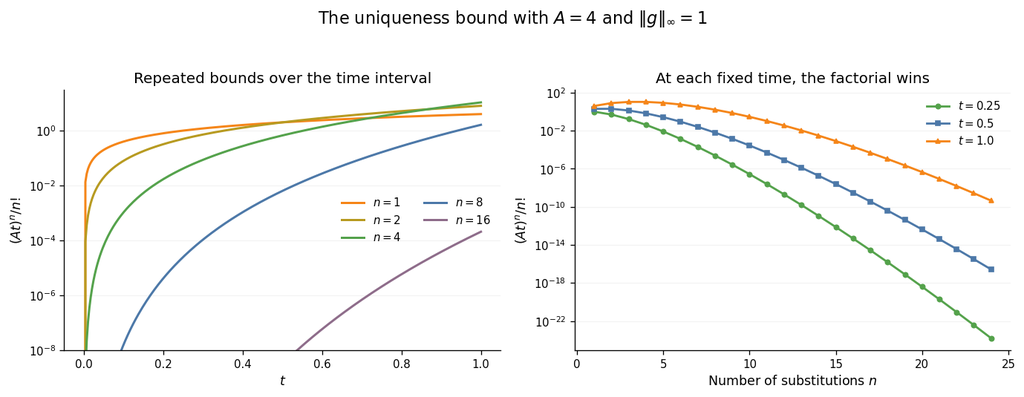

**Figure 4.** The normalized upper bounds $(At)^n/n!$ with $A=4$ for several substitution counts and fixed times.

Interpretation. The bound need not decrease during the first few substitutions; for example, at $t=1$ it initially grows. What matters is that, at every fixed time, factorial growth in $n!$ eventually dominates $(At)^n$ and sends the bound to zero. The proof uses this exact limiting argument. The figure only makes the sequence of deterministic bounds visible.

## 6. Constructing a solution by Picard iteration

For existence, Theorem 6.4 starts with $X_t^{(0)}=x_0$ and defines

$$ X_t^{(n+1)} =x_0+\int_0^t\mu\left(s,X_s^{(n)}\right)ds +\int_0^t\sigma\left(s,X_s^{(n)}\right)dB_s. $$

The proof has four dependencies. The growth condition makes every iterate well-defined and uniformly $L^2$-bounded. Lemma 6.5 then controls successive differences by

$$ g_n(t) :=\mathbb E\left[\sup_{0\leq s\leq t} \left|X_s^{(n+1)}-X_s^{(n)}\right|^2\right] \leq C\int_0^t g_{n-1}(s)\,ds. $$

Iteration produces a factorial bound. Markov's inequality and Borel-Cantelli give almost-sure uniform convergence of the paths, while $L^2$ convergence permits passage to the limits in the ordinary and Itô integrals.

For the martingale term, Doob's $L^2$ inequality is used in the squared form

$$ \mathbb E\left[\sup_{0\leq s\leq t}|M_s|^2\right] \leq4\mathbb E[|M_t|^2]. $$

Using $2$ instead of $4$ changes only the generic constant $C$ in Lemma 6.5, not the conclusion.

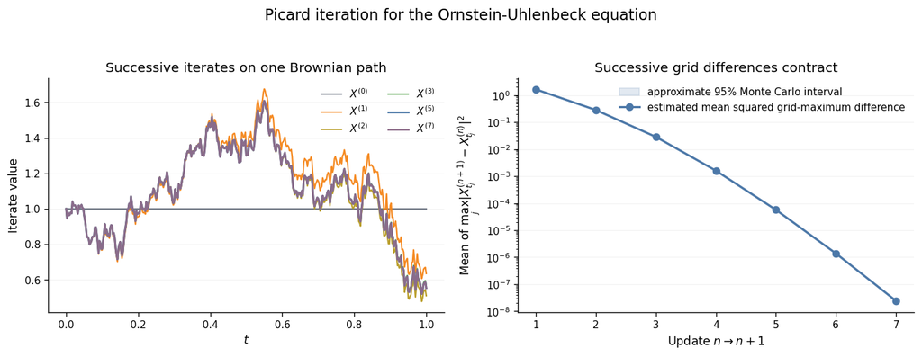

**Figure 5.** Grid-based Picard iterates for the OU equation with $x_0=1$, $\alpha=0.9$, and $\sigma=0.7$, together with estimates from 2,500 paths on a 400-interval grid.

Interpretation. On the left, later iterates become visually indistinguishable on the displayed Brownian path. On the right, the estimated mean squared grid-maximum difference contracts across updates; the bands quantify Monte Carlo uncertainty for that grid statistic. The ordinary integrals use left sums, so these values also contain time-discretisation error. The existence proof rests on Lemma 6.5 and the factorial bound, not on the simulation.

## 7. A boundary example: the Brownian bridge

Example 6.6 considers, for $0\leq t<1$,

$$ dX_t=-\frac{X_t}{1-t}\,dt+dB_t, \qquad X_0=0. $$

Matching coefficients in a product-Gaussian ansatz gives

$$ X_t=(1-t)\int_0^t\frac{1}{1-s}\,dB_s. $$

This is a centred Gaussian process. For $0\leq s\leq t<1$, the Itô isometry and independence of Brownian increments give

$$ \mathbb E[X_sX_t]=s(1-t), \qquad \operatorname{Var}(X_t)=t(1-t). $$

The zero mean follows because the Itô integral has zero mean. The process is not a martingale: when $s<t$,

$$ \mathbb E[X_sX_t]=s(1-t) \neq s(1-s)=\mathbb E[X_s^2]. $$

The drift coefficient is singular at $t=1$. On every interval $[0,T]$ with $T<1$, it satisfies Theorem 6.4 with a finite Lipschitz constant; the theorem does not apply on $[0,1]$ as written. The Brownian bridge nevertheless has a continuous extension with $X_1=0$.

For simulation, the code uses $B_t-tB_1$. This centred Gaussian process has covariance $\min(s,t)-st$, so it has the same finite-dimensional distributions as the process above.

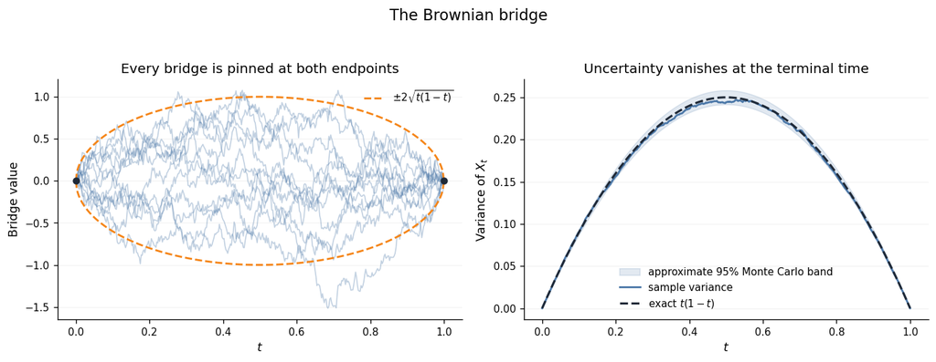

**Figure 6.** Brownian-bridge paths and variance estimates from 7,000 exact grid simulations, with the theoretical standard-deviation envelope and variance curve.

Interpretation. The paths are random in the interior but return to zero at $t=1$, where the exact variance $t(1-t)$ vanishes. The sample variance follows the exact curve within the displayed pointwise Monte Carlo band. The covariance calculation identifies the Brownian-bridge law and also shows why the process is not a martingale; the simulation displays the endpoint constraint.